# R Notebook

**Scatterplots to compare replicas**

```r
par(mfrow=c(3,4))

plot(x = normalized.gene.expression[,"ctl_water1"],
     y = normalized.gene.expression[,"ctl_water2"],
     pch=19,col="black",xlab="ctl_water1",ylab="ctl_water2",cex=0.5)
text(x=3,y=10,
     labels = paste(c(
      "cor = ",
      round(100*cor(normalized.gene.expression[,"ctl_water1"],
                    normalized.gene.expression[,"ctl_water2"]),
            digits = 2),
      "%"), collapse=""))


plot(x = normalized.gene.expression[,"ctl_water1"],
     y = normalized.gene.expression[,"ctl_water3"],
     pch=19,col="black",xlab="ctl_water1",ylab="ctl_water3",cex=0.5)
text(x=3,y=10,
     labels = paste(c(
       "cor = ",
       round(100*cor(normalized.gene.expression[,"ctl_water1"],
                     normalized.gene.expression[,"ctl_water3"]),
             digits = 2),
       "%"), collapse=""))


plot(x = normalized.gene.expression[,"ctl_water2"],
     y = normalized.gene.expression[,"ctl_water3"],
     pch=19,col="black",xlab="ctl_water2",ylab="ctl_water3",cex=0.5)
text(x=3,y=10,
     labels = paste(c(
       "cor = ",
       round(100*cor(normalized.gene.expression[,"ctl_water2"],
                     normalized.gene.expression[,"ctl_water3"]),
             digits = 2),
       "%"), collapse=""))


plot(x = normalized.gene.expression[,"ctl_drought1"],
     y = normalized.gene.expression[,"ctl_drought2"],
     pch=19,col="black",xlab="ctl_drought1",ylab="ctl_drought2",cex=0.5)
text(x=3,y=10,
     labels = paste(c(
       "cor = ",
       round(100*cor(normalized.gene.expression[,"ctl_drought1"],
                     normalized.gene.expression[,"ctl_drought2"]),
             digits = 2),
       "%"), collapse=""))


plot(x = normalized.gene.expression[,"ctl_drought1"],
     y = normalized.gene.expression[,"ctl_drought3"],
     pch=19,col="black",xlab="ctl_drought1",ylab="ctl_drought3",cex=0.5)
text(x=3,y=10,
     labels = paste(c(
       "cor = ",
       round(100*cor(normalized.gene.expression[,"ctl_drought1"],
                     normalized.gene.expression[,"ctl_drought3"]),
             digits = 2),
       "%"), collapse=""))


plot(x = normalized.gene.expression[,"ctl_drought2"],
     y = normalized.gene.expression[,"ctl_drought3"],
     pch=19,col="black",xlab="ctl_drought2",ylab="ctl_drought3",cex=0.5)
text(x=3,y=10,
     labels = paste(c(
       "cor = ",
       round(100*cor(normalized.gene.expression[,"ctl_drought2"],
                     normalized.gene.expression[,"ctl_drought3"]),
             digits = 2),
       "%"), collapse=""))


plot(x = normalized.gene.expression[,"h1_water1"],
     y = normalized.gene.expression[,"h1_water2"],
     pch=19,col="black",xlab="h1_water1",ylab="h1_water2",cex=0.5)
text(x=3,y=10,
     labels = paste(c(
       "cor = ",
       round(100*cor(normalized.gene.expression[,"h1_water1"],
                     normalized.gene.expression[,"h1_water2"]),
             digits = 2),
       "%"), collapse=""))


plot(x = normalized.gene.expression[,"h1_water1"],
     y = normalized.gene.expression[,"h1_water3"],
     pch=19,col="black",xlab="h1_water1",ylab="h1_water3",cex=0.5)
text(x=3,y=10,
     labels = paste(c(
       "cor = ",
       round(100*cor(normalized.gene.expression[,"h1_water1"],
                     normalized.gene.expression[,"h1_water3"]),
             digits = 2),
       "%"), collapse=""))


plot(x = normalized.gene.expression[,"h1_water2"],
     y = normalized.gene.expression[,"h1_water3"],
     pch=19,col="black",xlab="h1_water2",ylab="h1_water3",cex=0.5)
text(x=3,y=10,
     labels = paste(c(
       "cor = ",
       round(100*cor(normalized.gene.expression[,"h1_water2"],
                     normalized.gene.expression[,"h1_water3"]),
             digits = 2),
       "%"), collapse=""))


plot(x = normalized.gene.expression[,"h1_drought1"],
     y = normalized.gene.expression[,"h1_drought2"],
     pch=19,col="black",xlab="h1_drought1",ylab="h1_drought2",cex=0.5)
text(x=3,y=10,
     labels = paste(c(
       "cor = ",
       round(100*cor(normalized.gene.expression[,"h1_drought1"],
                     normalized.gene.expression[,"h1_drought2"]),
             digits = 2),
       "%"), collapse=""))


plot(x = normalized.gene.expression[,"h1_drought1"],
     y = normalized.gene.expression[,"h1_drought3"],
     pch=19,col="black",xlab="h1_drought1",ylab="h1_drought3",cex=0.5)
text(x=3,y=10,
     labels = paste(c(
       "cor = ",
       round(100*cor(normalized.gene.expression[,"h1_drought1"],
                     normalized.gene.expression[,"h1_drought3"]),
             digits = 2),
       "%"), collapse=""))


plot(x = normalized.gene.expression[,"h1_drought2"],
     y = normalized.gene.expression[,"h1_drought3"],
     pch=19,col="black",xlab="h1_drought2",ylab="h1_drought3",cex=0.5)
text(x=3,y=10,
     labels = paste(c(
       "cor = ",
       round(100*cor(normalized.gene.expression[,"h1_drought2"],
                     normalized.gene.expression[,"h1_drought3"]),
             digits = 2),
       "%"), collapse=""))
```

Then, we can see in most of the graphs very low dispersion between the points thus forming in most cases a figure similar to a straight line.

Finally, it should also be noted that the replica ctl_drought2 has a greater dispersion of data and therefore greater variability, given that at the time of the study it was observed that ctl_drought2 was more distant from the rest of the data.

**Principal Component Analysis and Hierarchical Clustering**

```r
library(FactoMineR)
library(factoextra)
```

```r
pca.gene.expression <- data.frame(colnames(normalized.gene.expression),
                                  t(normalized.gene.expression))
colnames(pca.gene.expression)[1] <- "Sample"
head(pca.gene.expression)
```

```r
res.pca <- PCA(pca.gene.expression, graph = FALSE,scale.unit = TRUE,quali.sup = 1 )
res.hcpc <- HCPC(res.pca, graph=FALSE,nb.clust = 4)
fviz_dend(res.hcpc,k=,
          cex = 0.75,
          palette = "Set1",
          rect = TRUE, rect_fill = TRUE,
          rect_border = "Set1",
          type="rectangle",
          labels_track_height = 1400
)
```

In addition, a disturbance is also visible in the cluster concerning “water”, where h1_water3 is deviated from its condition group h1_water. The same is true for ctl_water1 which is closer to the h1_water cluster. This is due to the variability of data obtained in these conditions.

```r
fviz_pca_ind(res.pca,
             col.ind = c("ctl_water", "ctl_water", "ctl_water", "ctl_drought", "ctl_drought", "ctl_drought", "h1_water", "h1_water", "h1_water", "h1_drought", "h1_drought", "h1_drought"),
             pointsize = 2,
             pointshape = 21,
             fill = "black",
             repel = TRUE,
             addEllipses = TRUE,
             ellipse.type = "confidence",
             legend.title = "Conditions",
             title = "",
             show.legend = TRUE,
             show.guide = TRUE
)
```

Again, we see that the ctl_drought2 condition is quite dispersed with respect to the replicates of the same condition, forming an ellipse that looks more like a straight line.

Unlike the dendogram, we see in this plot that the replicates are well clustered.

### Differential Gene Expression Analysis

**Comparison of the generated transcriptome with the reference transcriptome**

Before proceeding further with the data analysis, it is useful to confirm that the annotation used (i.e. downloaded from the database) is suitable for the study. To do this, we can compare the transcriptome in the database with the transcripts that have been detected in total in the study (in all samples).

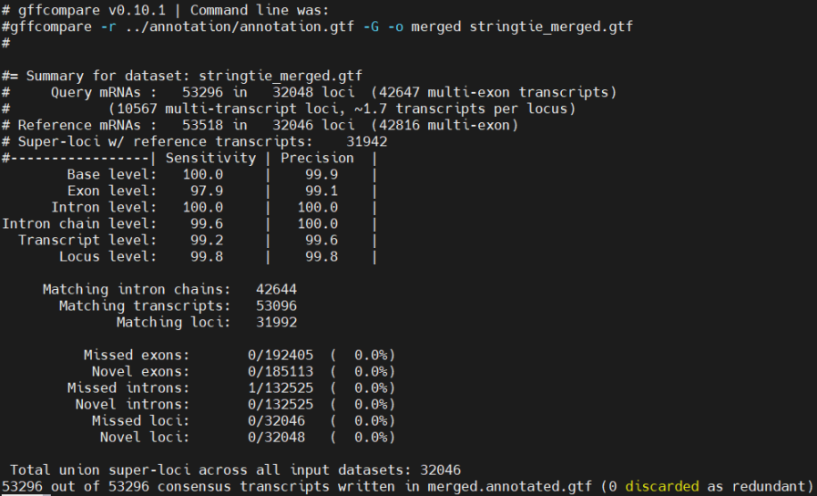

**Mapping visualisation**

We can see the result of the mapping in IGV. The following image shows some of the reads that have mapped to the AT4G33100 gene.

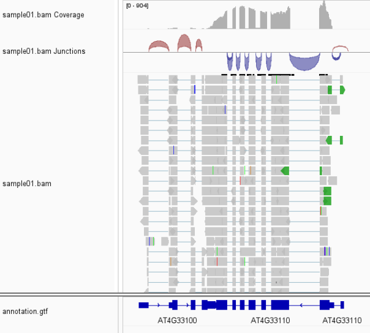

Each line represents a read, so that the grey rectangles are genome sequences found in the read and the lines between the rectangles correspond to fragments that are present in the genome, but not in the reads. As can be seen in the annotation, these areas correspond to the introns of the gene (blue lines).

### Differential Gene Expression Analysis

First, we will use scatterplots to visualise the effect of the different treatments performed in the study.

```r
# We calculate the average expression of each gene in each condition
ctl_water <- (normalized.gene.expression[,"ctl_water1"] + normalized.gene.expression[,"ctl_water2"]+ normalized.gene.expression[,"ctl_water3"])/3

ctl_drought <- (normalized.gene.expression[,"ctl_drought1"] + normalized.gene.expression[,"ctl_drought2"]+ normalized.gene.expression[,"ctl_drought3"])/3

h1_water <- (normalized.gene.expression[,"h1_water1"] + normalized.gene.expression[,"h1_water2"]+ normalized.gene.expression[,"h1_water3"])/3

h1_drought <- (normalized.gene.expression[,"h1_drought1"] + normalized.gene.expression[,"h1_drought2"]+ normalized.gene.expression[,"h1_drought3"])/3

mean.expression <- matrix(c(ctl_water,ctl_drought, h1_water,h1_drought),ncol=4)
colnames(mean.expression) <- c("ctl_water","ctl_drought","h1_water","h1_drought")
rownames(mean.expression) <- rownames(normalized.gene.expression)
head(mean.expression)


par(mfrow=c(2,3))

plot(ctl_water,ctl_drought,pch=19,cex=0.7,xlab="ctl_water",
     ylab="ctl_drought",cex.lab=1.25,col="black")

plot(h1_water,h1_drought,pch=19,cex=0.7,xlab="h1_water",
     ylab="h1_drought",cex.lab=1.25,col="black")

plot(ctl_drought,h1_drought,pch=19,cex=0.7,xlab="ctl_drought",
     ylab="h1_drought",cex.lab=1.25,col="black")

plot(ctl_water,h1_water,pch=19,cex=0.7,xlab="ctl_water",
     ylab="h1_water",cex.lab=1.25,col="black")

plot(ctl_water,h1_drought,pch=19,cex=0.7,xlab="ctl_water",
     ylab="h1_drought",cex.lab=1.25,col="black")
```

```r
library(limma)
# We define the experimental design and determine the comparisons to be made.
experimental.design <- model.matrix(~ -1+factor(c(1,1,1,2,2,2,3,3,3,4,4,4)))
colnames(experimental.design) <- c("ctl_water","ctl_drought","h1_water","h1_drought")
linear.fit <- lmFit(normalized.gene.expression, experimental.design)
contrast.matrix <- makeContrasts(ctl_drought-ctl_water, h1_drought-h1_water, h1_drought-ctl_drought,h1_water-ctl_water, h1_drought-ctl_water,levels=c("ctl_water","ctl_drought","h1_water","h1_drought"))
contrast.linear.fit <- contrasts.fit(linear.fit, contrast.matrix)
contrast.results <- eBayes(contrast.linear.fit)
```

**Comparison 1. CTL_Drought vs CTL_Water**

The aim of this first comparison is to identify the genes involved in drought response.

```r
ctl_drought.ctl_water <- topTable(contrast.results, number=32833,coef=1,sort.by="logFC")
log.fold.change <- ctl_drought.ctl_water$logFC
q.value <- ctl_drought.ctl_water$adj.P.Val
genes.ids <- rownames(ctl_drought.ctl_water)
names(log.fold.change) <- genes.ids
names(q.value) <- genes.ids
activated.c1 <- genes.ids[log.fold.change > log2(1.5) & q.value < 0.1]
repressed.c1 <- genes.ids[log.fold.change < - log2(1.5) & q.value < 0.1]
length(activated.c1)
length(repressed.c1)

log.q.val <- -log10(q.value)
plot(log.fold.change,log.q.val,pch=19,col="black",cex=0.8,
     xlim=c(-6,6),ylim = c(0,4),
     xlab="log2(Fold-chage)",ylab="-log10(q-value)",cex.lab=1.5,
     main="CTL_drought vs CTL_water")

points(x = log.fold.change[activated.c1],
       y = log.q.val[activated.c1],col="red",cex=0.8,pch=19)
points(x = log.fold.change[repressed.c1],
       y = log.q.val[repressed.c1],col="blue",cex=0.8,pch=19)
arrows(log.fold.change["AT5G02020"],log.q.val["AT5G02020"],2.5,1.2,length=0)
text(2.8,1.2,"SIS",cex=0.7)
arrows(log.fold.change["AT4G17500"],log.q.val["AT4G17500"],2,2,length=0)
text(2.5,2.3,"ERF-1",cex=0.7)
arrows(log.fold.change["AT4G08950"],log.q.val["AT4G08950"],-2,2,length=0)
text(-2,2.3,"EX0",cex=0.7)

write.table(activated.c1,file="activated_ctl_drought_ctl_water.txt",row.names = FALSE,quote=FALSE,col.names = FALSE)
write.table(repressed.c1,file="repressed_ctl_drought_ctl_water.txt",row.names = FALSE,quote=FALSE,col.names = FALSE)
```

**Comparison 2. H1_drought vs H1_water**

The objective in this case is to determine which genes are involved in the drought response when plants have been inoculated with *Aeromonas*.

```r
h1_drought.h1_water <- topTable(contrast.results, number=32833,coef=2,sort.by="logFC")
log.fold.change <- h1_drought.h1_water$logFC
q.value <- h1_drought.h1_water$adj.P.Val
genes.ids <- rownames(h1_drought.h1_water)
names(log.fold.change) <- genes.ids
names(q.value) <- genes.ids
activated.c2 <- genes.ids[log.fold.change > log2(1.5) & q.value < 0.1]
repressed.c2 <- genes.ids[log.fold.change < - log2(1.5) & q.value < 0.1]
length(activated.c2)
length(repressed.c2)

log.q.val <- -log10(q.value)
plot(log.fold.change,log.q.val,pch=19,col="black",cex=0.8,
     xlim=c(-6,6),ylim = c(0,4),
     xlab="log2(Fold-chage)",ylab="-log10(q-value)",cex.lab=1.5,
     main="H1_drought vs H1_water")

points(x = log.fold.change[activated.c2],
       y = log.q.val[activated.c2],col="red",cex=0.8,pch=19)
points(x = log.fold.change[repressed.c2],
       y = log.q.val[repressed.c2],col="blue",cex=0.8,pch=19)
arrows(log.fold.change["AT3G23550"],log.q.val["AT3G23550"],2.5,2.5,length=0)
text(2.9,2.5,"DTX18",cex=0.7)
arrows(log.fold.change["AT1G73500"],log.q.val["AT1G73500"],2.3,1.8,length=0)
text(2.6,1.8,"MKK9",cex=0.7)
arrows(log.fold.change["AT5G15600"],log.q.val["AT5G15600"],-2,1,length=0)
text(-2,1,"EX0",cex=0.7)


write.table(activated.c2,file="activated_h1_drought_h1_water.txt",row.names = FALSE,quote=FALSE,col.names = FALSE)
write.table(repressed.c2,file="repressed_h1_drought_h1_water.txt",row.names = FALSE,quote=FALSE,col.names = FALSE)
```

Using the selected criteria, we found 282 activated genes and 45 repressed genes. In this case, one of the activated genes is the mitogen-activated protein kinase MKK9, which has intracellular signalling function.

**Comparison 3. H1_drought vs CTL_drought.**

With this comparison, we analysed the effect of inoculating *Aeromonas* into *Arabidopsis* roots under drought conditions. Thus, we looked for genes whose expression is changed by *Aeromonas*.

```r
h1_drought.ctl_drought <- topTable(contrast.results, number=32833,coef=3,sort.by="logFC")
log.fold.change <- h1_drought.ctl_drought$logFC
q.value <- h1_drought.ctl_drought$adj.P.Val
genes.ids <- rownames(h1_drought.ctl_drought)
names(log.fold.change) <- genes.ids
names(q.value) <- genes.ids
activated.c3 <- genes.ids[log.fold.change > log2(1.5) & q.value < 0.1]
repressed.c3 <- genes.ids[log.fold.change < - log2(1.5) & q.value < 0.1]
length(activated.c3)
length(repressed.c3)

log.q.val <- -log10(q.value)
plot(log.fold.change,log.q.val,pch=19,col="black",cex=0.8,
     xlim=c(-6,6),ylim = c(0,4),
     xlab="log2(Fold-chage)",ylab="-log10(q-value)",cex.lab=1.5,
     main="CTL_drought vs H1_drought")

points(x = log.fold.change[activated.c3],
       y = log.q.val[activated.c3],col="red",cex=0.8,pch=19)
points(x = log.fold.change[repressed.c3],
       y = log.q.val[repressed.c3],col="blue",cex=0.8,pch=19)
arrows(log.fold.change["AT3G15500"],log.q.val["AT3G15500"],2.5,2.5,length=0)
text(2.9,2.5,"NAC3",cex=0.7)

write.table(activated.c3,file="activated_h1_drought_ctl_drought.txt",row.names = FALSE,quote=FALSE,col.names = FALSE)
write.table(repressed.c3,file="repressed_h1_drought_ctl_drought.txt",row.names = FALSE,quote=FALSE,col.names = FALSE)
```

In this comparison, 84 activated genes and 28 repressed genes were detected. The activated genes include NAC3, a transcription factor involved in developmental processes.

**Comparison 4. H1_water vs CTL_water**

With this fourth comparison, we studied the effect of inoculation with *Aeromonas* when *Arabidopsis* is under basal conditions.

```r
h1_water.ctl_water <- topTable(contrast.results, number=32833,coef=4,sort.by="logFC")
log.fold.change <- h1_water.ctl_water$logFC
q.value <- h1_water.ctl_water$adj.P.Val
genes.ids <- rownames(h1_water.ctl_water)
names(log.fold.change) <- genes.ids
names(q.value) <- genes.ids
activated.c4 <- genes.ids[log.fold.change > log2(1.5) & q.value < 0.1]
repressed.c4 <- genes.ids[log.fold.change < - log2(1.5) & q.value < 0.1]
length(activated.c4)
length(repressed.c4)

log.q.val <- -log10(q.value)
plot(log.fold.change,log.q.val,pch=19,col="black",cex=0.8,
     xlim=c(-6,6),ylim = c(0,4),
     xlab="log2(Fold-chage)",ylab="-log10(q-value)",cex.lab=1.5,
     main="H1_water vs CTL_water")

points(x = log.fold.change[activated.c4],
       y = log.q.val[activated.c4],col="red",cex=0.8,pch=19)
points(x = log.fold.change[repressed.c4],
       y = log.q.val[repressed.c4],col="blue",cex=0.8,pch=19)
```

**Comparison 5. H1_drought vs CTL_water**

Finally, we compared gene expression in control plants (irrigated and uninoculated) with plants inoculated with *Aeromonas* and under drought conditions. In this way, we can observe a synergistic effect between the drought treatment and the effect produced by the bacteria.

```r
h1_drought.ctl_water <- topTable(contrast.results, number=32833,coef=5,sort.by="logFC")
log.fold.change <- h1_drought.ctl_water$logFC
q.value <- h1_drought.ctl_water$adj.P.Val
genes.ids <- rownames(h1_drought.ctl_water)
names(log.fold.change) <- genes.ids
names(q.value) <- genes.ids
activated.c5 <- genes.ids[log.fold.change > log2(1.5) & q.value < 0.1]
repressed.c5 <- genes.ids[log.fold.change < - log2(1.5) & q.value < 0.1]
length(activated.c5)
length(repressed.c5)

log.q.val <- -log10(q.value)
plot(log.fold.change,log.q.val,pch=19,col="black",cex=0.8,
     xlim=c(-6,6),ylim = c(0,4),
     xlab="log2(Fold-chage)",ylab="-log10(q-value)",cex.lab=1.5,
     main="H1_drought vs CTL_water")

points(x = log.fold.change[activated.c5],
       y = log.q.val[activated.c5],col="red",cex=0.8,pch=19)
points(x = log.fold.change[repressed.c5],
       y = log.q.val[repressed.c5],col="blue",cex=0.8,pch=19)
arrows(log.fold.change["AT1G74930"],log.q.val["AT1G74930"],3.8,3.6,length=0)
text(4.3,3.7,"ORA47",cex=0.7)
arrows(log.fold.change["AT5G47220"],log.q.val["AT5G47220"],4,3,length=0)
text(4,2.8,"ERF2",cex=0.7)


write.table(activated.c5,file="activated_h1_drought_ctl_water.txt",row.names = FALSE,quote=FALSE,col.names = FALSE)
write.table(repressed.c5,file="repressed_h1_drought_ctl_water.txt",row.names = FALSE,quote=FALSE,col.names = FALSE)
```

In the latter comparison, 556 activated genes and 150 repressed genes have been identified. The gene ORA47, a transcription factor that also belongs to the family known as ERF/AP2, stands out.

**Analysis using DESeq2**

```r
library(DESeq2)
gene.count.matrix <- read.table(file = "gene_count_matrix.csv",header = T,sep = ",")
gene.ids <- sapply(X = strsplit(x = gene.count.matrix$gene_id,split = "\\|"),FUN = function(x){return(x[1])})

gene.count.matrix <- gene.count.matrix[,-1]
rownames(gene.count.matrix) <- gene.ids

dds <- DESeqDataSetFromMatrix(countData=gene.count.matrix, colData=pheno.data, design = ~ aeromonas + drought)
dds$aeromonas <- relevel(dds$aeromonas, ref = "ctl")
dds$drought <- relevel(dds$drought, ref = "ctl")

dds <- DESeq(dds)
mod_mat <- model.matrix(design(dds), colData(dds))
ctl_water <- colMeans(mod_mat[dds$aeromonas == "ctl" & dds$drought == "ctl", ])
ctl_drought <- colMeans(mod_mat[dds$aeromonas == "ctl" & dds$drought == "drought", ])
h1_water <- colMeans(mod_mat[dds$aeromonas == "h1" & dds$drought == "ctl", ])
h1_drought <- colMeans(mod_mat[dds$aeromonas == "h1" & dds$drought == "drought", ])

# Comparison 1
res1 <- results(dds, contrast = ctl_drought - ctl_water)
genes.ids <- rownames(res1)
log.fold.change <- res1$log2FoldChange
q.value <- res1$padj
names(log.fold.change) <- genes.ids
names(q.value) <- genes.ids
activated.c1.deseq2 <- genes.ids[log.fold.change > log2(1.5) & q.value < 0.1]
activated.c1.deseq2 <- activated.c1.deseq2[!is.na(activated.c1.deseq2)]
repressed.c1.deseq2 <- genes.ids[log.fold.change < - log2(1.5) & q.value < 0.1]
repressed.c1.deseq2 <- repressed.c1.deseq2[!is.na(repressed.c1.deseq2)]
length(activated.c1.deseq2)
length(repressed.c1.deseq2)

# Comparison 2
res2 <- results(dds, contrast = h1_drought - h1_water)
genes.ids <- rownames(res2)
log.fold.change <- res2$log2FoldChange
q.value <- res2$padj
names(log.fold.change) <- genes.ids
names(q.value) <- genes.ids
activated.c2.deseq2 <- genes.ids[log.fold.change > log2(1.5) & q.value < 0.1]
activated.c2.deseq2 <- activated.c2.deseq2[!is.na(activated.c2.deseq2)]
repressed.c2.deseq2 <- genes.ids[log.fold.change < - log2(1.5) & q.value < 0.1]
repressed.c2.deseq2 <- repressed.c2.deseq2[!is.na(repressed.c2.deseq2)]
length(activated.c2.deseq2)
length(repressed.c2.deseq2)

# Comparison 3
res3 <- results(dds, contrast = h1_drought - ctl_drought)
genes.ids <- rownames(res3)
log.fold.change <- res3$log2FoldChange
q.value <- res3$padj
names(log.fold.change) <- genes.ids
names(q.value) <- genes.ids
activated.c3.deseq2 <- genes.ids[log.fold.change > log2(1.5) & q.value < 0.1]
activated.c3.deseq2 <- activated.c3.deseq2[!is.na(activated.c3.deseq2)]
repressed.c3.deseq2 <- genes.ids[log.fold.change < - log2(1.5) & q.value < 0.1]
repressed.c3.deseq2 <- repressed.c3.deseq2[!is.na(repressed.c3.deseq2)]
length(activated.c3.deseq2)
length(repressed.c3.deseq2)

# Comparison 4
res4 <- results(dds, contrast = h1_water - ctl_water)
genes.ids <- rownames(res4)
log.fold.change <- res4$log2FoldChange
q.value <- res4$padj
names(log.fold.change) <- genes.ids
names(q.value) <- genes.ids
activated.c4.deseq2 <- genes.ids[log.fold.change > log2(1.5) & q.value < 0.1]
activated.c4.deseq2 <- activated.c4.deseq2[!is.na(activated.c4.deseq2)]
repressed.c4.deseq2 <- genes.ids[log.fold.change < - log2(1.5) & q.value < 0.1]
repressed.c4.deseq2 <- repressed.c4.deseq2[!is.na(repressed.c4.deseq2)]
length(activated.c4.deseq2)
length(repressed.c4.deseq2)

# Comparison 5
res5 <- results(dds, contrast = h1_drought - ctl_water)
genes.ids <- rownames(res5)
log.fold.change <- res5$log2FoldChange
q.value <- res5$padj
names(log.fold.change) <- genes.ids
names(q.value) <- genes.ids
activated.c5.deseq2 <- genes.ids[log.fold.change > log2(1.5) & q.value < 0.1]
activated.c5.deseq2 <- activated.c5.deseq2[!is.na(activated.c5.deseq2)]
repressed.c5.deseq2 <- genes.ids[log.fold.change < - log2(1.5) & q.value < 0.1]
repressed.c5.deseq2 <- repressed.c5.deseq2[!is.na(repressed.c5.deseq2)]
length(activated.c5.deseq2)
length(repressed.c5.deseq2)
```

**Results comparison limma vs DESeq2**

```r
library(ggvenn)
ggvenn(list(limma=c(activated.c2,repressed.c2),DESeq2=c(activated.c2.deseq2,repressed.c2.deseq2)))
```

```r
ggvenn(list(limma=c(activated.c5,repressed.c5),DESeq2=c(activated.c5.deseq2,repressed.c5.deseq2)))
```

Furthermore, in this particular study, we have observed that the effect on the transcriptome is relatively subtle. In case of a more pronounced effect, where we could set more restrictive fold-change and q-value thresholds, we might observe better agreement between analyses.

**Comparisons between gene sets**

```r
ggvenn(list(degs_drought=c(activated.c1,repressed.c1),degs_h1_drought=c(activated.c5,repressed.c5)))
```

In this Venn diagram, we compare two sets of genes:

- DEGs Ctl_water vs Ctl_drought
- DEGs Ctl_water vs H1_drought

### Gene Ontology Term Enrichment Analysis

Gene ontology allows the systematic and unambiguous incorporation of information into genes by annotation. It consists of a structured (from more generic to more specific) and controlled vocabulary of terms that describe gene products in terms of biological processes, cellular components and molecular functions.

An enrichment of gene ontology terms aims to improve the representation of genetic information, making it more accurate and complete, so that it is possible to effectively interpret the results.

```r
library(clusterProfiler)
library(org.At.tair.db)
library(enrichplot)
```

**Differentially activated genes H1_drought vs CTL_drought**

Here we perform GO term enrichment of the differentially activated gene set in *Arabidopsis thaliana* plants inoculated with *Aeromonas* sp. under drought conditions compared to non-inoculated plants under drought conditions.

```r
activated_h1_d_ctl_d <- read.table(file="activated_h1_drought_ctl_drought.txt")[[1]]

activated_h1_d_ctl_d.atha.enrich.go <- enrichGO(gene          = activated_h1_d_ctl_d,
                                                OrgDb         = org.At.tair.db,
                                                ont           = "BP",
                                                pAdjustMethod = "BH",
                                                pvalueCutoff  = 0.05,
                                                readable      = FALSE,
                                                keyType = "TAIR")

df.1 <- as.data.frame(activated_h1_d_ctl_d.atha.enrich.go)

write.table(as.data.frame(df.1$pvalue,df.1$ID), file = "activated_h1_d_ctl_d_revigo", quote = FALSE)
```

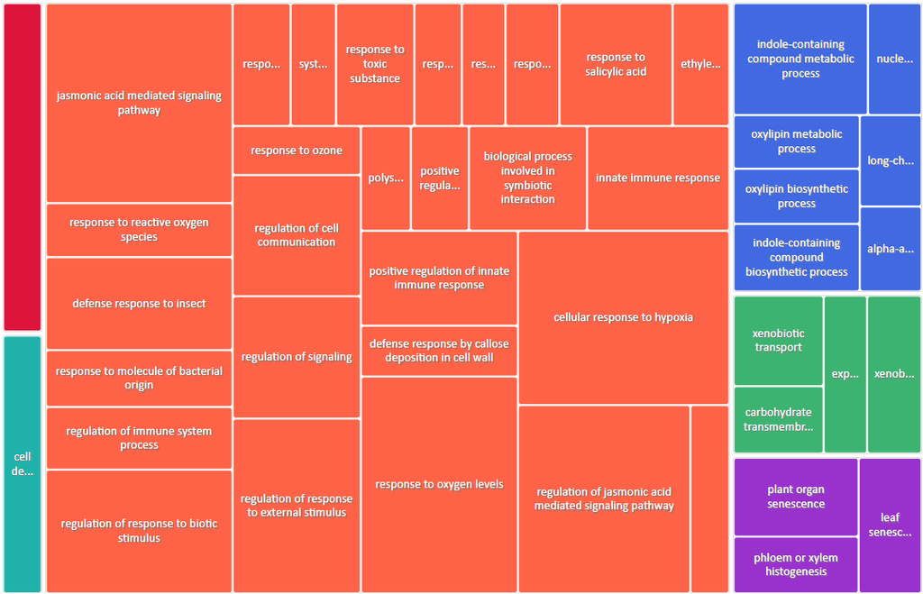

ReVIGO screenshot.

| GO Term and q-value | Description | Representative Genes |
| --- | --- | --- |
| GO:0002376 7.369807e-05 | immune system process | ERF2/PEN3/CYP81F2 |
| GO:0008219 0.0005994776 | cell death | PEN3/PLA2A/NUDT7 |
| GO:0009867 1.141716e-12 | jasmonic acid mediated signaling pathway | JAZ7/ERF2/NAC3 |
| GO:0042430 3.081945e-05 | indole-containing compound metabolic process | HSPRO2/PEN3/CYP81F2 |
| GO:0042908 0.004019064 | xenobiotic transport | DTX18 |
| GO:0090693 0.001098587 | plant organ senescence | BGLU11/MKK9/NAC6 |

The table shows the most represented biological process from each group of interrelated processes that are significantly altered. Among the most represented, the jasmonic acid (JA)-mediated signalling pathway is significantly enriched compared to the others by having the lowest qvalue. These observations can be corroborated by looking at the treemap image, which shows that the largest block of all is the one corresponding to this pathway. Moreover, the size of the same group (blocks of the same colour) clearly occupies almost the entire image indicating that these are very important processes for the resistance to water stress provided by *Aeromonas* sp., which is why they are mostly activated pathways.

Furthermore, the GO analysis highlights JA-related DEGs, such as JAZ7, ERF2 and NAC3, which are known to promote plant resistance to dehydration stress. NAC3 has been obtained previously in analyses of differentially activated genes for these conditions, and ERF2 appears to be involved in other enriched processes as well. We can also highlight PEN3 as regulating several important processes.

**Differentially repressed genes H1_drought vs CTL_drought**

Here we perform GO term enrichment of the set of differentially repressed genes in *Arabidopsis thaliana* plants inoculated with *Aeromonas* sp. under drought conditions compared to non-inoculated plants under drought conditions.

```r
repressed_h1_d_ctl_d <- read.table(file="repressed_h1_drought_ctl_drought.txt")[[1]]

repressed_h1_d_ctl_d.atha.enrich.go <- enrichGO(gene          = repressed_h1_d_ctl_d,
                                                OrgDb         = org.At.tair.db,
                                                ont           = "BP",
                                                pAdjustMethod = "BH",
                                                pvalueCutoff  = 0.05,
                                                readable      = FALSE,
                                                keyType = "TAIR")

df.2 <- as.data.frame(repressed_h1_d_ctl_d.atha.enrich.go)

write.table(as.data.frame(df.2$pvalue,df.2$ID), file="repressed_h1_d_ctl_d_revigo", quote=FALSE)
```

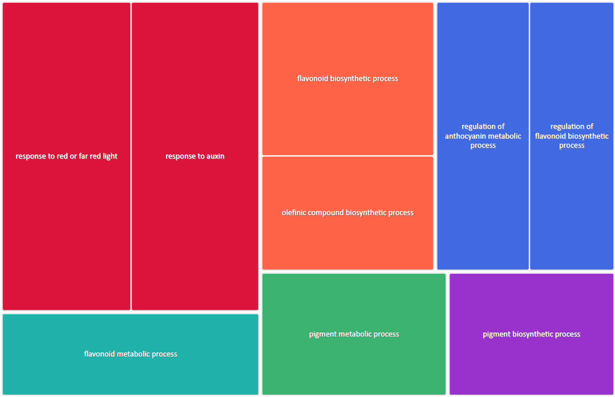

ReVIGO screenshot.

| GO Term and q-value | Description | Representative Genes |
| --- | --- | --- |
| GO:0009639 0.0002585459 | response to red or far red light | ERF34/ERD9/BBX32 |
| GO:0009813 0.009531447 | flavonoid biosynthetic process | TT4/FLS1 |
| GO:0031537 0.0118085 | regulation of anthocyanin metabolic process | TT4 |

In this case it is possible to see both in the treemap and in the table that there is an enrichment of repressed genes in response to red or far-red light in the inoculated plants, followed by the process of flavonoid biosynthesis.

**Differentially activated genes H1_drought vs CTL_water**

Here we perform GO term enrichment of the differentially activated gene set in *Arabidopsis thaliana* plants inoculated with *Aeromonas* sp. under drought conditions compared to non-inoculated and irrigated plants.

```r
activated_h1_d_ctl_w <- read.table(file="activated_h1_drought_ctl_water.txt")[[1]]

activated_h1_d_ctl_w.atha.enrich.go <- enrichGO(gene          = activated_h1_d_ctl_w,
                                                OrgDb         = org.At.tair.db,
                                                ont           = "BP",
                                                pAdjustMethod = "BH",
                                                pvalueCutoff  = 0.05,
                                                readable      = FALSE,
                                                keyType = "TAIR")

df.3 <- as.data.frame(activated_h1_d_ctl_w.atha.enrich.go)

write.table(as.data.frame(df.3$pvalue,df.3$ID), file="activated_h1_d_ctl_w_revigo", quote=FALSE)
```

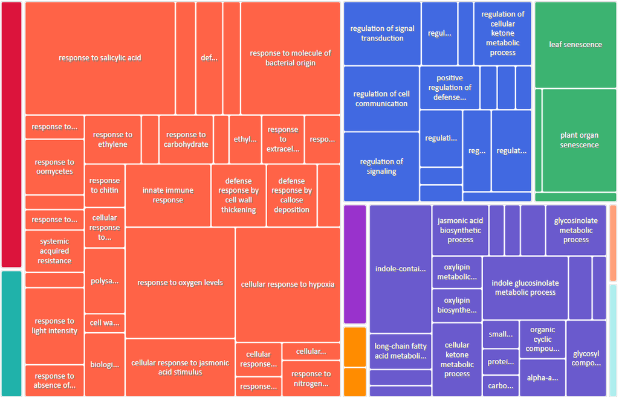

ReVIGO screenshot.

| GO Term and q-value | Description | Representative Genes |
| --- | --- | --- |
| GO:0002376 4.074928e-18 | immune system process | ERF2/PLA2A/PEN3 |
| GO:0008219 1.272887e-08 | cell death | PLA2A/PEN3/NAC6 |
| GO:0009751 2.481618e-49 | response to salicylic acid | BT2/ATS40.4/SYP122 |
| GO:0009966 1.864563e-14 | regulation of signal transduction | JAZ7/JAZ1/JAZ6 |
| GO:0010150 3.679929e-21 | leaf senescence | RD26/MKK9/SAG21 |
| GO:0012501 8.360128e-09 | programmed cell death | PLA2A/PEN3/NAC6 |
| GO:0034219 0.003716663 | carbohydrate transmembrane transport | ERD6/STP1/ESL1 |
| GO:0042430 2.39423e-23 | indole-containing compound metabolic process | IGMT1/UGT74E2/MKK9 |
| GO:0045229 0.01758479 | external encapsulating structure organization | PEN3/TCH4/CYP81F2 |

The response to salicylic acid is noteworthy for its high enrichment compared to the rest of the processes, as is the whole group compared to the rest of the groups.

In relation to the most representative genes, we can highlight ERF2 corresponding to the activation of the immune system, one of the most enriched processes. On the other hand, we again see the JAZ7 gene, as in the comparison of H1_drought vs CTL_drought activated genes, which suggests that it is fundamental for the response to water stress.

**Differentially repressed genes H1_drought vs CTL_water**

Here we perform GO term enrichment of the set of differentially repressed genes in *Arabidopsis thaliana* plants inoculated with *Aeromonas* sp. under drought conditions compared to non-inoculated and irrigated plants.

```r
repressed_h1_d_ctl_w <- read.table(file="repressed_h1_drought_ctl_water.txt")[[1]]

repressed_h1_d_ctl_w.atha.enrich.go <- enrichGO(gene          = repressed_h1_d_ctl_w,
                                                OrgDb         = org.At.tair.db,
                                                ont           = "BP",
                                                pAdjustMethod = "BH",
                                                pvalueCutoff  = 0.05,
                                                readable      = FALSE,
                                                keyType = "TAIR")

df.4 <- as.data.frame(repressed_h1_d_ctl_w.atha.enrich.go)

write.table(as.data.frame(df.4$pvalue,df.4$ID), file="repressed_h1_d_ctl_w_revigo", quote=FALSE)
```

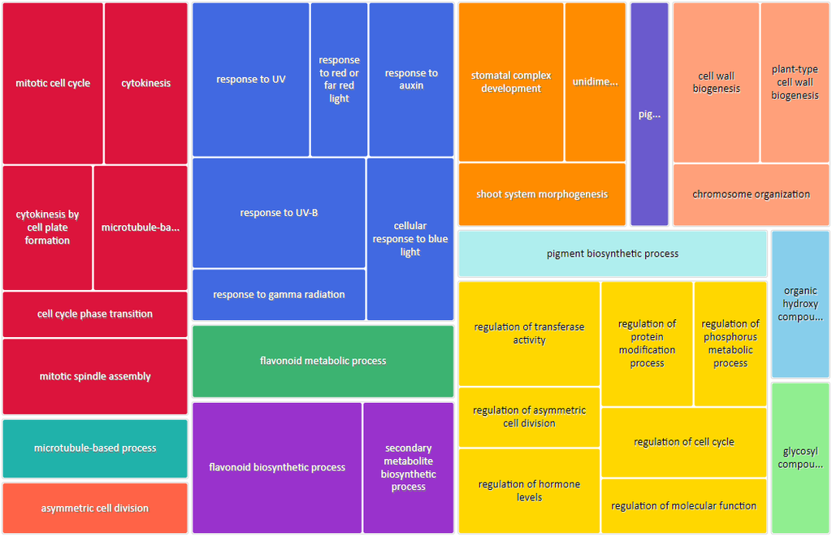

ReVIGO screenshot.

| GO Term and q-value | Description | Representative Genes |
| --- | --- | --- |
| GO:0000278 0.001719728 | mitotic cell cycle | CYCA1;1/TPX2/CYCB1;1 |
| GO:0007017 0.01155884 | microtubule-based process | TPX2/SP1L4/PAKRP2 |
| GO:0008356 0.01895755 | asymmetric cell division | TMM/BASL |
| GO:0009411 0.0008523922 | response to UV | ELIP1/MYB4/F3H |
| GO:0009813 0.0001719778 | flavonoid biosynthetic process | FLS1/F3H/RHM1 |
| GO:0010374 0.001380033 | stomatal complex development | TMM/CKX6/EPF2 |
| GO:0042546 0.004344226 | cell wall biogenesis | ERF34/AGP17/RGP1 |
| GO:0051338 0.003546343 | regulation of transferase activity | CYCA1;1/TPX2/CDC20.1 |

In this case, no major differences are observed in the enrichment of processes or groups of processes, the q-values being quite similar and the treemap quite homogeneous in terms of size. Although the most enriched processes coincide with those of the H1_drought vs CTL_drought differentially repressed gene condition.

**Enrichment of KEGG route terms**

```r
# Differentially activated genes H1_drought vs CTL_drought
activated_h1_d_ctl_d.atha.enrich.kegg <- enrichKEGG(gene  = activated_h1_d_ctl_d,
                                                    organism = "ath",
                                                    pAdjustMethod = "BH",
                                                    pvalueCutoff  = 0.05)

df.activated_h1_d_ctl_d.atha.enrich.kegg <- as.data.frame(activated_h1_d_ctl_d.atha.enrich.kegg)

# Differentially activated genes H1_drought vs CTL_water
activated_h1_d_ctl_w.atha.enrich.kegg <- enrichKEGG(gene  = activated_h1_d_ctl_w,
                                                    organism = "ath",
                                                    pAdjustMethod = "BH",
                                                    pvalueCutoff  = 0.05)

df.activated_h1_d_ctl_w.atha.enrich.kegg <- as.data.frame(activated_h1_d_ctl_w.atha.enrich.kegg)
```

Visualisation of the alpha-linolenic acid metabolism pathway.

```r
library(pathview)
```

```r
pathview(gene.data = sort(log.fold.change,decreasing = TRUE),
         pathway.id = "ath00592",
         species = "ath",
         limit = list(gene=max(abs(log.fold.change)), cpd=1), gene.idtype = "TAIR")
```

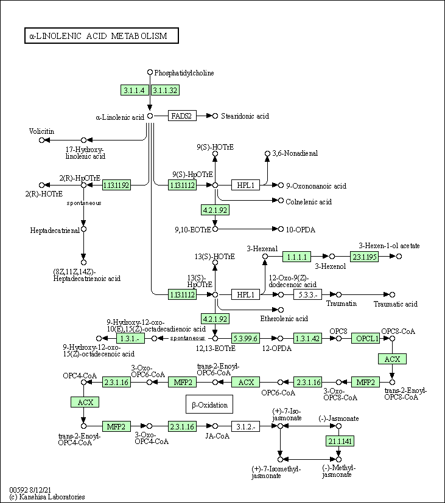

```r
# Differentially repressed genes H1_drought vs CTL_drought
repressed_h1_d_ctl_w.atha.enrich.kegg <- enrichKEGG(gene  = repressed_h1_d_ctl_w,
                                                    organism = "ath",
                                                    pAdjustMethod = "BH",
                                                    pvalueCutoff  = 0.05)

df.repressed_h1_d_ctl_w.atha.enrich.kegg <- as.data.frame(repressed_h1_d_ctl_w.atha.enrich.kegg)

# Differentially repressed genes H1_drought vs CTL_water
repressed_h1_d_ctl_d.atha.enrich.kegg <- enrichKEGG(gene  = repressed_h1_d_ctl_d,
                                                    organism = "ath",
                                                    pAdjustMethod = "BH",
                                                    pvalueCutoff  = 0.05)

df.repressed_h1_d_ctl_d.atha.enrich.kegg <- as.data.frame(repressed_h1_d_ctl_d.atha.enrich.kegg)
```

Visualisation of the flavonoid biosynthesis pathway.

```r
pathview(gene.data = sort(log.fold.change,decreasing = TRUE),
         pathway.id = "ath00941",
         species = "ath",
         limit = list(gene=max(abs(log.fold.change)), cpd=1), gene.idtype = "TAIR")
```

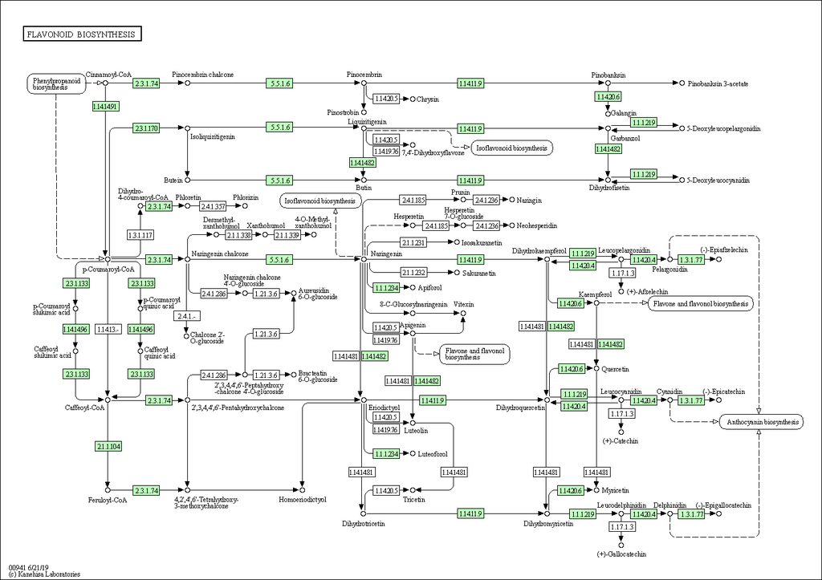

## Conclusions

With the analyses carried out, we have obtained the differentially expressed genes for drought stress conditions and when inoculated with *Aeromonas* sp. We have observed how *Arabidopsis thaliana* under drought conditions is able to produce a stronger response to this abiotic stress (differentially expresses more genes) when treated with *Aeromonas* sp.

By studying the enrichment of GO terms, we have been able to verify that, to our surprise, the genes that are activated when plants are inoculated with *Aeromonas* under drought conditions are involved in the response to water stress. Our enrichment analyses have also revealed that jasmonic acid plays an important role in this process. On the other hand, we have seen that when comparing conditions in which the plant is watered, treatment with *Aeromonas* sp. does not have a detrimental effect on the plant.

A simple but effective experiment that would help us to explain the effects that *Aeromonas* sp would have on *Arabidopsis thaliana*, would be to compare two plants under dehydration conditions, one of them being treated with the bacterium and the other not. To do this, we would transplant the two plants, one week old and previously grown under the same conditions, to exactly the same medium. After this step, one of the plants is inoculated with a certain controlled amount of *Aeromonas* sp and from that moment on, the dehydration conditions begin. After about 2 weeks of cultivation, the plants are watered again. In this way, it can be seen that the plant inoculated with the bacteria shows a recovery process that the plant without *Aeromonas* is unable to achieve.

## Reference

He, D., Kaushal, R., Peng, L., Singh, SK., et al (2022). Flavonoid-attracted Aeromonas sp. from the Arabidopsis root microbiome enhances plants dehydration resistance. The ISME Journal (cursiva), Volume 16, Issue 11, pp.2622-2632